# Linear Regression Lecture Demo

Cody Carroll

This data set provides measurements of the diameter, height and volume of timber in 31 felled black cherry trees.

```r
library(ggplot2)
library(tidyverse)
?trees

trees
```

| Girth | Height | Volume |
| --- | --- | --- |
| 8.3 | 70 | 10.3 |
| 8.6 | 65 | 10.3 |
| 8.8 | 63 | 10.2 |
| 10.5 | 72 | 16.4 |
| 10.7 | 81 | 18.8 |
| 10.8 | 83 | 19.7 |
| 11.0 | 66 | 15.6 |
| 11.0 | 75 | 18.2 |
| 11.1 | 80 | 22.6 |
| 11.2 | 75 | 19.9 |

[output cut: 21 more lines]

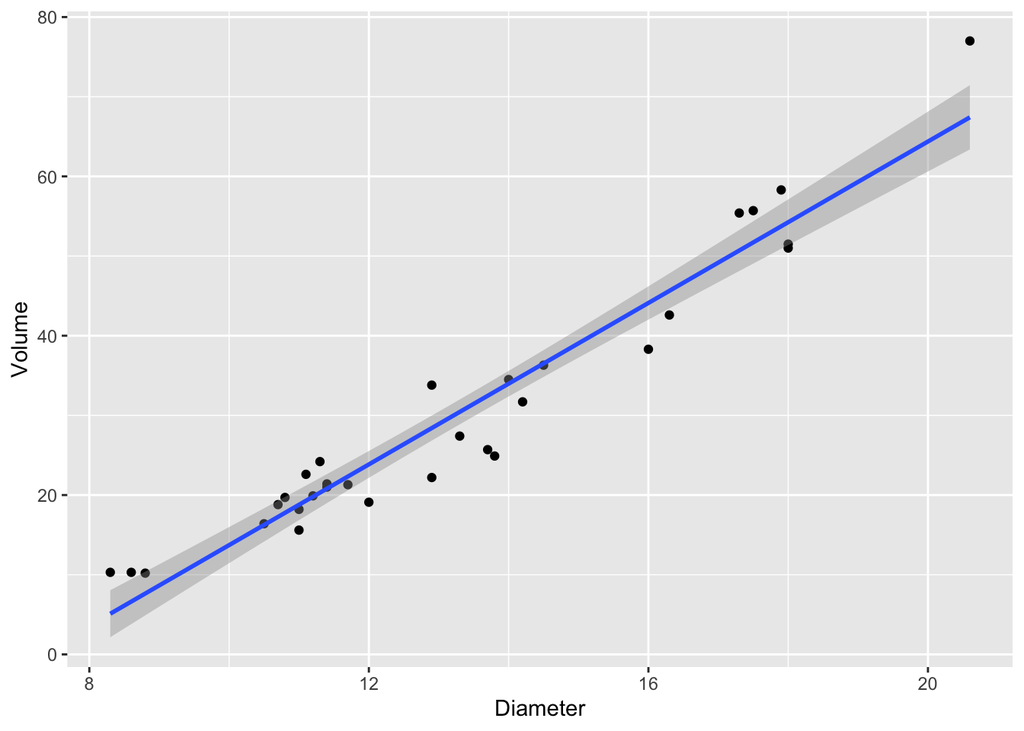

```r
treedata=trees
colnames(treedata) = c("Diameter",  "Height", "Volume")

ggplot(treedata, aes(x=Diameter, y=Volume)) +
  geom_point() +
  geom_smooth(method = "lm")
```

Fit a linear model, add the least squares regression line:

```r
treeline = lm(Volume ~ Diameter, data=treedata)
#lm(y ~ x, data = data)
treedata$predicted = predict(treeline)   # Save the predicted values
treedata$residuals = residuals(treeline) # add residuals to the data.frame

treedata
```

| Diameter | Height | Volume | predicted | residuals |
| --- | --- | --- | --- | --- |
| 8.3 | 70 | 10.3 | 5.103149 | 5.1968508 |
| 8.6 | 65 | 10.3 | 6.622906 | 3.6770939 |
| 8.8 | 63 | 10.2 | 7.636077 | 2.5639226 |
| 10.5 | 72 | 16.4 | 16.248033 | 0.1519667 |
| 10.7 | 81 | 18.8 | 17.261205 | 1.5387954 |
| 10.8 | 83 | 19.7 | 17.767790 | 1.9322098 |
| 11.0 | 66 | 15.6 | 18.780962 | -3.1809615 |
| 11.0 | 75 | 18.2 | 18.780962 | -0.5809615 |
| 11.1 | 80 | 22.6 | 19.287547 | 3.3124528 |
| 11.2 | 75 | 19.9 | 19.794133 | 0.1058672 |

[output cut: 21 more lines]

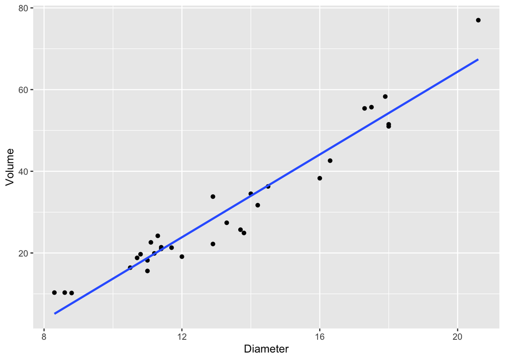

```r
#add the regression line to the plot with geom_smooth

ggplot(treedata, aes(x=Diameter, y=Volume)) +
  geom_point() +
  geom_smooth(method = "lm", se = FALSE)
```

```r
summary(treeline)
```

```
##
## Call:
## lm(formula = Volume ~ Diameter, data = treedata)
##
## Residuals:
##    Min     1Q Median     3Q    Max
## -8.065 -3.107  0.152  3.495  9.587
##
## Coefficients:
##             Estimate Std. Error t value Pr(>|t|)
## (Intercept) -36.9435     3.3651  -10.98 7.62e-12 ***
## Diameter      5.0659     0.2474   20.48  < 2e-16 ***
## ---
## Signif. codes:  0 '***' 0.001 '**' 0.01 '*' 0.05 '.' 0.1 ' ' 1
##
## Residual standard error: 4.252 on 29 degrees of freedom
## Multiple R-squared:  0.9353, Adjusted R-squared:  0.9331
## F-statistic: 419.4 on 1 and 29 DF,  p-value: < 2.2e-16
```

```r
#predict the volume for the 10th tree in my dataset
treedata[10,]
```

|  | Diameter | Height | Volume | predicted | residuals |
| --- | --- | --- | --- | --- | --- |
| 10 | 11.2 | 75 | 19.9 | 19.79413 | 0.1058672 |

```r
-36.94+5.07*(11.2)
```

```
## [1] 19.844
```

```r
treedata[11,]
```

|  | Diameter | Height | Volume | predicted | residuals |
| --- | --- | --- | --- | --- | --- |
| 11 | 11.3 | 79 | 24.2 | 20.30072 | 3.899282 |

```r
-36.94+5.07*(11.3)
```

```
## [1] 20.351
```

Interpret the meaning of slope and intercept.

Slope: On average, for every 1 in increase in the diameter of a tree, we expect its volume to increase by 5.0659 cubic ft.

```r
-36.9435 + 5.0659*12 #predicted vol for a 12in diam tree, 23.8473
```

```
## [1] 23.8473
```

```r
-36.9435 + 5.0659*13 #predicted vol for a 13in diam tree, 28.9132
```

```
## [1] 28.9132
```

```r
28.9132 - 23.8473
```

```
## [1] 5.0659
```

```r
##Q: What is the expected increase or decrease in volume of a tree if I
##increase its diameter by 5 in?

#slope * change in x  = expected difference in y

5.0659 * 5
```

```
## [1] 25.3295
```

```r
-36.9435 + 5.0659*12 #predicted vol for a 12in diam tree, 23.8473
```

```
## [1] 23.8473
```

```r
-36.9435 + 5.0659*17 #predicted vol for a 17in diam tree, 49.1768
```

```
## [1] 49.1768
```

```r
49.1768 - 23.8473
```

```
## [1] 25.3295
```

```r
#Q: What is the unit of the slope? 5.0659 cu. ft / in.
#
```

Intercept:

The intercept is calculated as -36.9435 cu ft.

How do I interpret this value?

The intercept value is the predicted volume of a tree with diameter 0in. This is nonsense!! The intercept is not interpretable in this problem.

Let’s try it with your class data. What’s the relationship between shoe size and height for people in this class?

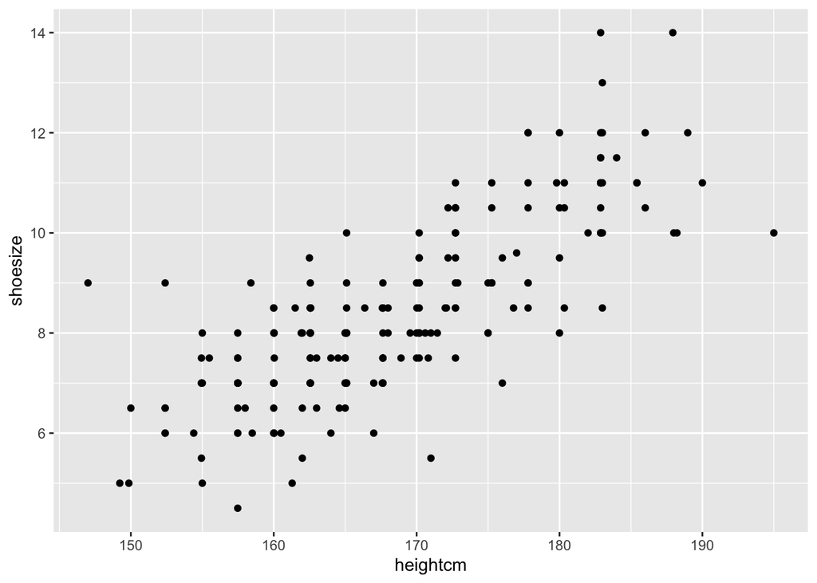

```r
survey = read.csv("~/Desktop/repos/master-intro-ds/Data/casestudy1_data.csv")

ggplot(survey, aes(x=heightcm, y=shoesize)) +
  geom_point()
```

```r
surveyline=lm(shoesize ~ heightcm, data = survey)
summary(surveyline)
```

```
##
## Call:
## lm(formula = shoesize ~ heightcm, data = survey)
##
## Residuals:
##     Min      1Q  Median      3Q     Max
## -3.2775 -0.7623 -0.0464  0.6805  3.6983
##
## Coefficients:
##               Estimate Std. Error t value Pr(>|t|)
## (Intercept) -15.987124   1.365250  -11.71   <2e-16 ***
## heightcm      0.144822   0.008091   17.90   <2e-16 ***
## ---
## Signif. codes:  0 '***' 0.001 '**' 0.01 '*' 0.05 '.' 0.1 ' ' 1
##
## Residual standard error: 1.116 on 201 degrees of freedom
## Multiple R-squared:  0.6145, Adjusted R-squared:  0.6126
## F-statistic: 320.4 on 1 and 201 DF,  p-value: < 2.2e-16
```

```r
surveyline$coefficients
```

```
## (Intercept)    heightcm
## -15.9871239   0.1448222
```

```r
surveyline$coefficients[1] + surveyline$coefficients[2] * 160
```

```
## (Intercept)
##    7.184431
```

Predict a new value: What shoe size would we expect someone who is 180cm (6’) to have?

```r
summary(surveyline)
```

```
##
## Call:
## lm(formula = shoesize ~ heightcm, data = survey)
##
## Residuals:
##     Min      1Q  Median      3Q     Max
## -3.2775 -0.7623 -0.0464  0.6805  3.6983
##
## Coefficients:
##               Estimate Std. Error t value Pr(>|t|)
## (Intercept) -15.987124   1.365250  -11.71   <2e-16 ***
## heightcm      0.144822   0.008091   17.90   <2e-16 ***
## ---
## Signif. codes:  0 '***' 0.001 '**' 0.01 '*' 0.05 '.' 0.1 ' ' 1
##
## Residual standard error: 1.116 on 201 degrees of freedom
## Multiple R-squared:  0.6145, Adjusted R-squared:  0.6126
## F-statistic: 320.4 on 1 and 201 DF,  p-value: < 2.2e-16
```

```r
-14.85663 + 0.13809 * 180 #predicted shoesize of a 180cm person
```

```
## [1] 9.99957
```

Doing it by hand:

```r
-14.85663+0.13809*(180) #~size 10
```

```
## [1] 9.99957
```

Doing it by extracting the “coefficients”:

```r
surveyline$coefficients[1] + surveyline$coefficients[2] * 180
```

```
## (Intercept)
##    10.08088
```

Doing it by using the predict function:

```r
newdf = data.frame(heightcm = 180)
predict(surveyline, newdf)
```

```
##        1
## 10.08088
```

```r
#first model, second newdf with x values you want to predict at

xs = c(150,160,170,180,190)
newdf_manyxs = data.frame(heightcm = xs)
yhats = predict(surveyline, newdf_manyxs)
cbind(xs, yhats)
```

```
##    xs     yhats
## 1 150  5.736209
## 2 160  7.184431
## 3 170  8.632653
## 4 180 10.080876
## 5 190 11.529098
```

Which pair of variables are more strongly related? Tree girth & volume? Or student height & shoe size?

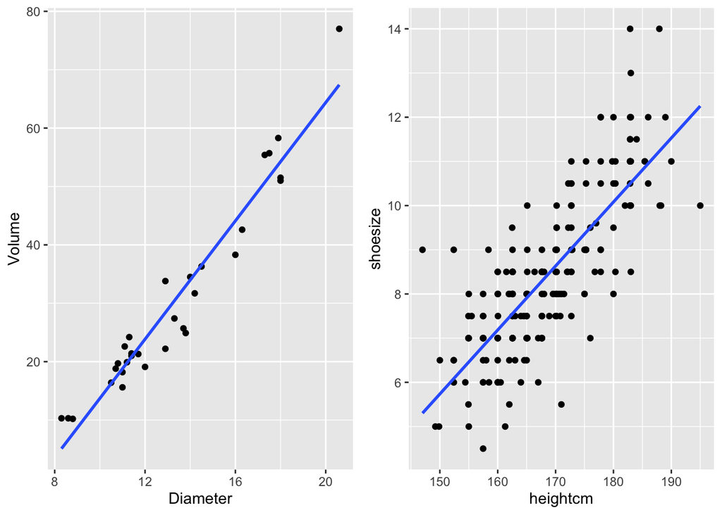

```r
gg1 = ggplot(treedata, aes(x=Diameter, y=Volume)) +
  geom_point() +
  geom_smooth(method = "lm", se = FALSE)

gg2 = ggplot(survey, aes(x=heightcm, y=shoesize)) +
  geom_point() +
  geom_smooth(method = "lm", se = FALSE)

library(ggpubr)
ggarrange(gg1, gg2)
```

The strength of the /linear/ relationship is measured by the $R^2$ statistic:

```r
summary(treeline) #0.9353
```

```
##
## Call:
## lm(formula = Volume ~ Diameter, data = treedata)
##
## Residuals:
##    Min     1Q Median     3Q    Max
## -8.065 -3.107  0.152  3.495  9.587
##
## Coefficients:
##             Estimate Std. Error t value Pr(>|t|)
## (Intercept) -36.9435     3.3651  -10.98 7.62e-12 ***
## Diameter      5.0659     0.2474   20.48  < 2e-16 ***
## ---
## Signif. codes:  0 '***' 0.001 '**' 0.01 '*' 0.05 '.' 0.1 ' ' 1
##
## Residual standard error: 4.252 on 29 degrees of freedom
## Multiple R-squared:  0.9353, Adjusted R-squared:  0.9331
## F-statistic: 419.4 on 1 and 29 DF,  p-value: < 2.2e-16
```

```r
summary(surveyline) #0.5955
```

```
##
## Call:
## lm(formula = shoesize ~ heightcm, data = survey)
##
## Residuals:
##     Min      1Q  Median      3Q     Max
## -3.2775 -0.7623 -0.0464  0.6805  3.6983
##
## Coefficients:
##               Estimate Std. Error t value Pr(>|t|)
## (Intercept) -15.987124   1.365250  -11.71   <2e-16 ***
## heightcm      0.144822   0.008091   17.90   <2e-16 ***
## ---
## Signif. codes:  0 '***' 0.001 '**' 0.01 '*' 0.05 '.' 0.1 ' ' 1
##
## Residual standard error: 1.116 on 201 degrees of freedom
## Multiple R-squared:  0.6145, Adjusted R-squared:  0.6126
## F-statistic: 320.4 on 1 and 201 DF,  p-value: < 2.2e-16
```

```r
summary(treeline)$r.squared
```

```
## [1] 0.9353199
```

```r
summary(surveyline)$r.squared
```

```
## [1] 0.6144833
```

```r
#R^2 is always locked between 0 and 1 (for linear regression.)
#R^2 closer to 0: very weak linear relationship between x and y.
#R^2 is closer to 1: very strong linear relationship between x and y.


#Exercise:
#In your survey data find a pair of variables x and y such that the R^2 value is nearly 1.

library(GGally)
```

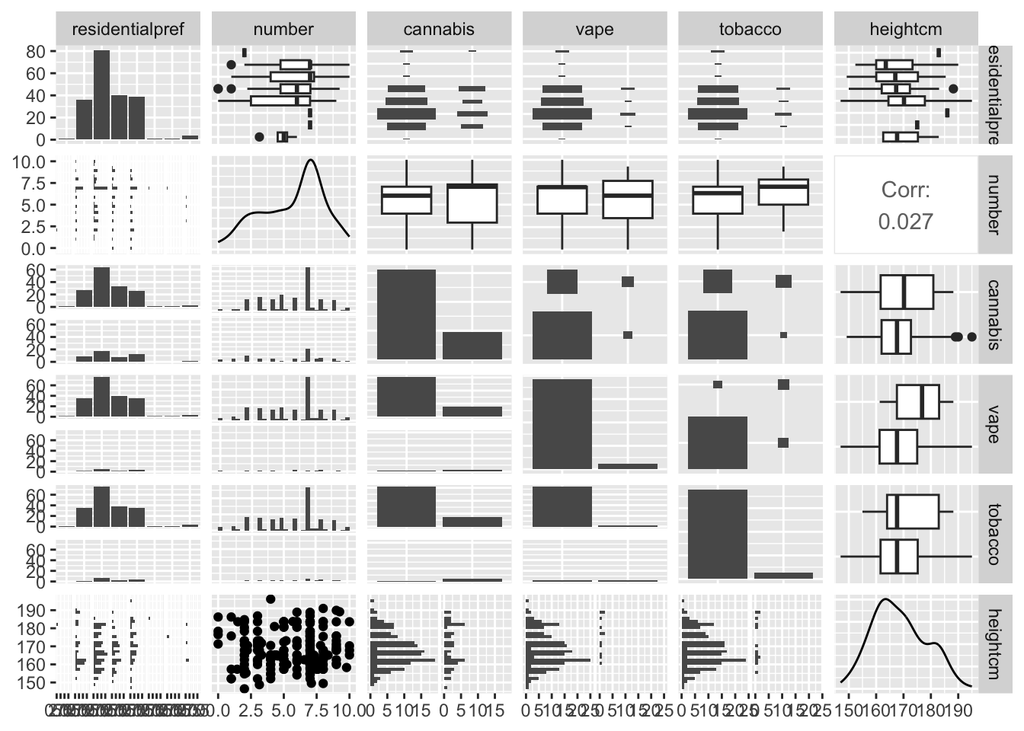

```r
ggpairs(survey[,10:15])
```

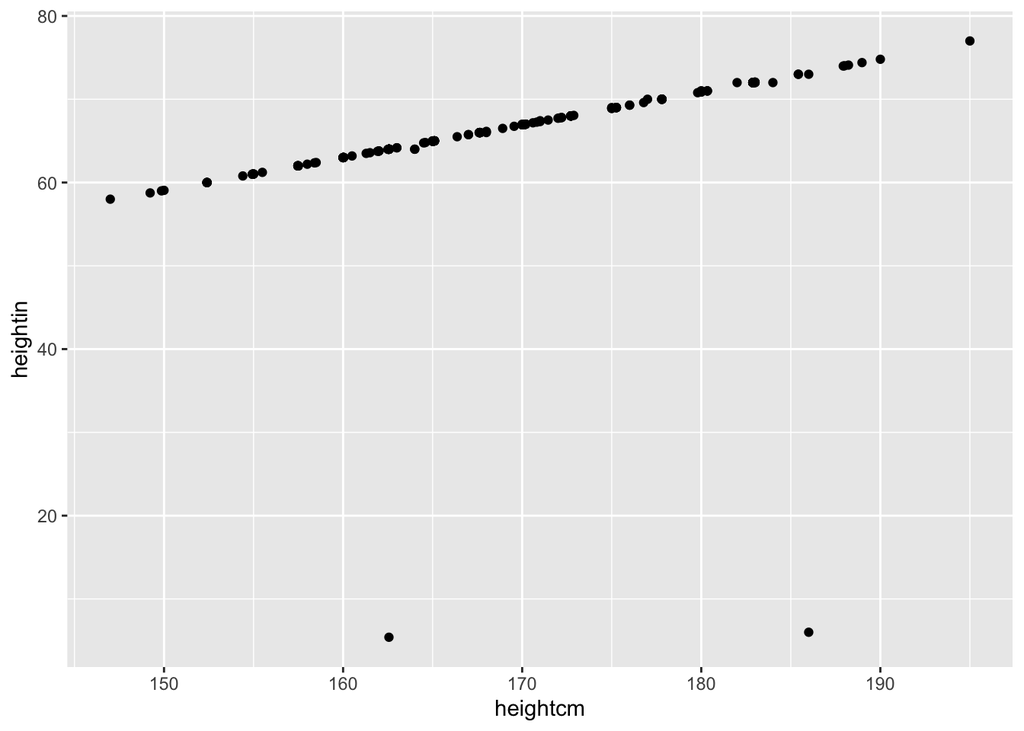

```r
ggplot(survey, aes(x = heightcm, y = heightin)) +
  geom_point()
```

```r
#How to remove that outlier??

#manual filtering
survey[survey$heightin<20, ]
```

|  | X.1 | X | class | tattoos | sleep | smoke | music | shoesize | piercing | residentialpref | number | cannabis | vape | tobacco | heightcm | heightin |
| --- | --- | --- | --- | --- | --- | --- | --- | --- | --- | --- | --- | --- | --- | --- | --- | --- |
| 108 | 48 | 48 | Junior | 0 | 8 | No. | Other | 8.5 | 0 | Urban/City | 2 | FALSE | FALSE | FALSE | 162.56 | 5.4 |
| 160 | 188 | 188 | Super Senior+ | 0 | 7 | Yes\\, cannabis.,Yes\\, vapes.,Yes\\, tobacco/cigarettes. | Electronic | 10.5 | 2 | Urban/City | 3 | TRUE | TRUE | TRUE | 186.00 | 6.0 |

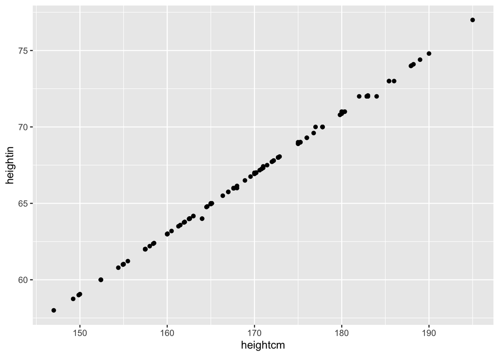

```r
survey_no_outlier = survey[-48, ]

#idx based filtering
idx = which(survey$heightin<20)
survey_no_outlier = survey[-idx, ]

#using dplyr functions
survey_no_outlier = survey %>% filter(heightin>20)

ggplot(survey_no_outlier, aes(x = heightcm, y = heightin)) +
  geom_point()
```

```r
mod = lm(heightin ~ heightcm, data = survey_no_outlier)
summary(mod)
```

```
##
## Call:
## lm(formula = heightin ~ heightcm, data = survey_no_outlier)
##
## Residuals:
##      Min       1Q   Median       3Q      Max
## -0.56325 -0.00061  0.00263  0.00535  0.34259
##
## Coefficients:
##               Estimate Std. Error t value Pr(>|t|)
## (Intercept) -0.0724146  0.0982384  -0.737    0.462
## heightcm     0.3941199  0.0005824 676.707   <2e-16 ***
## ---
## Signif. codes:  0 '***' 0.001 '**' 0.01 '*' 0.05 '.' 0.1 ' ' 1
##
## Residual standard error: 0.07963 on 199 degrees of freedom
## Multiple R-squared:  0.9996, Adjusted R-squared:  0.9996
## F-statistic: 4.579e+05 on 1 and 199 DF,  p-value: < 2.2e-16
```

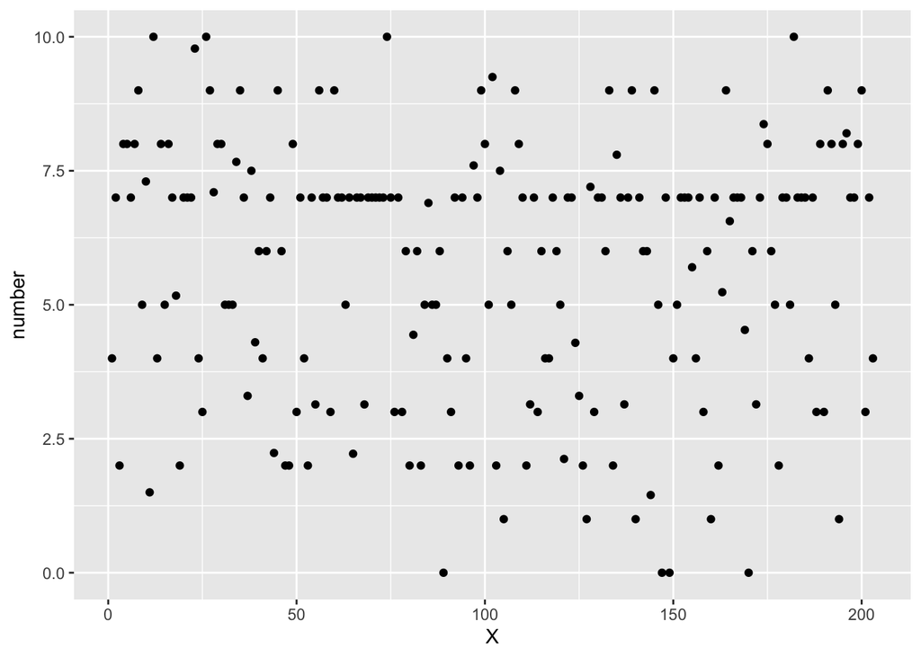

```r
#Exercise: find a pair of x and y variables where R^2 is very close to 0.


ggplot(survey, aes(x = X, y = number)) +
  geom_point()
```

```r
randomlm = lm(number ~ shoesize, data = survey)
summary(randomlm)
```

```
##
## Call:
## lm(formula = number ~ shoesize, data = survey)
##
## Residuals:
##    Min     1Q Median     3Q    Max
## -5.753 -1.661  1.146  1.398  4.348
##
## Coefficients:
##             Estimate Std. Error t value Pr(>|t|)
## (Intercept)  5.38338    0.81518   6.604  3.5e-10 ***
## shoesize     0.03362    0.09481   0.355    0.723
## ---
## Signif. codes:  0 '***' 0.001 '**' 0.01 '*' 0.05 '.' 0.1 ' ' 1
##
## Residual standard error: 2.417 on 201 degrees of freedom
## Multiple R-squared:  0.0006252,  Adjusted R-squared:  -0.004347
## F-statistic: 0.1257 on 1 and 201 DF,  p-value: 0.7233
```

$R^2$ is also called the “coefficient of determination.”

It can be interpreted as the fraction of variation in $y$ explained by the regression line.

$R^2$ has a somewhat technical definition; has to do with residuals and variance of $y$. Not our focus here.

#FYI # $R^2 = 1 - SSE/SST$

# Residual plot

The residual plot shows the x-values vs. the residuals:

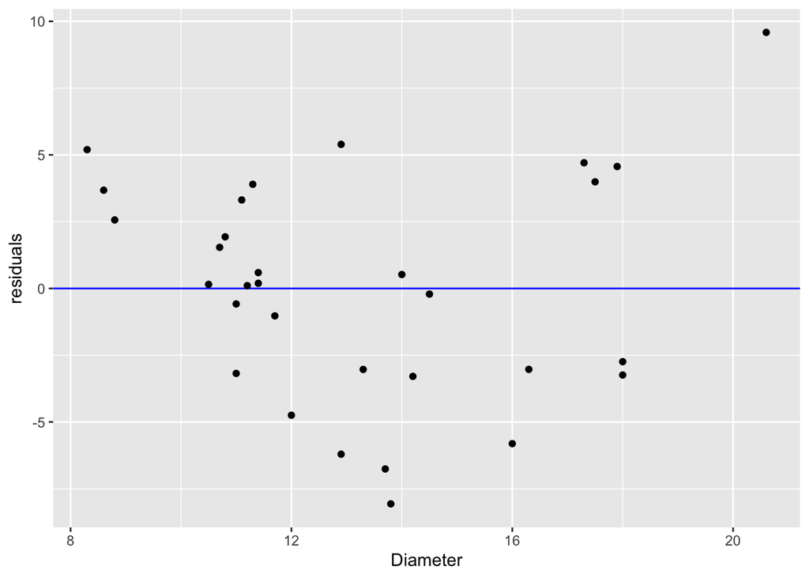

```r
ggplot(treedata, aes(x=Diameter, y=residuals))  +
  geom_hline(aes(yintercept = 0), color="blue") +
  geom_point()
```

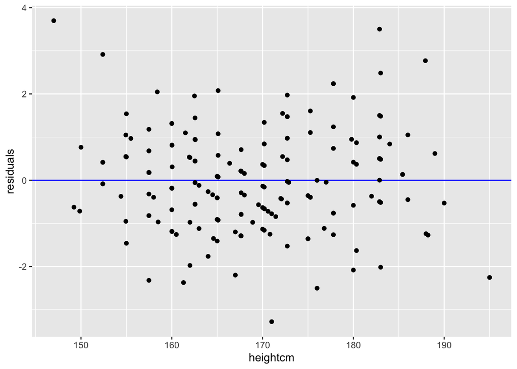

```r
survey$residuals = residuals(surveyline)
ggplot(survey, aes(x=heightcm, y=residuals))  +
  geom_hline(aes(yintercept = 0), color="blue") +
  geom_point()
```

If you’re getting an error, make sure you’ve actually added the residuals to your original data frame!! Otherwise ggplot cannot find them.

Let’s visualize residuals on the original scatter plot for the tree data.

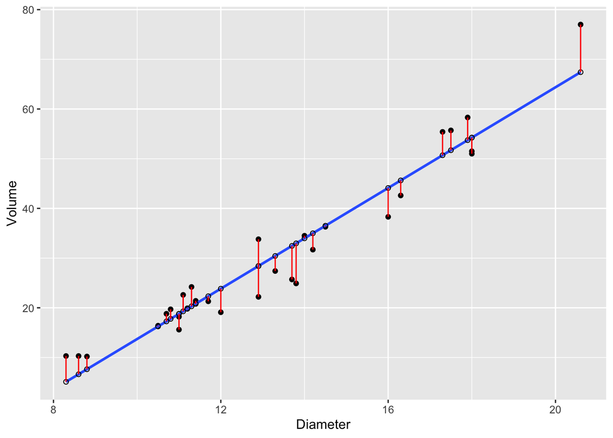

```r
ggplot(treedata, aes(x=Diameter, y=Volume)) +
  geom_point() +
  geom_smooth(method = "lm", se = FALSE) +
  geom_point(aes(y = predicted), shape = 1) +
  geom_segment(aes(xend = Diameter, yend = predicted), color = "red")
```

How does this relate back to our original linear regression plot?

#key takeaway when you make a residual plot Pattern in residuals -> bad. Some assumption has been violated. It means linear regression (in its current form) isn’t appropriate.

Example of this: Women’s heights and weights

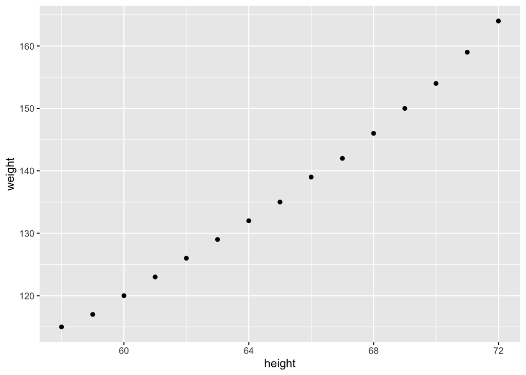

```r
?women

womendata=women
ggplot(womendata, aes(x=height, y=weight)) +
  geom_point()
```

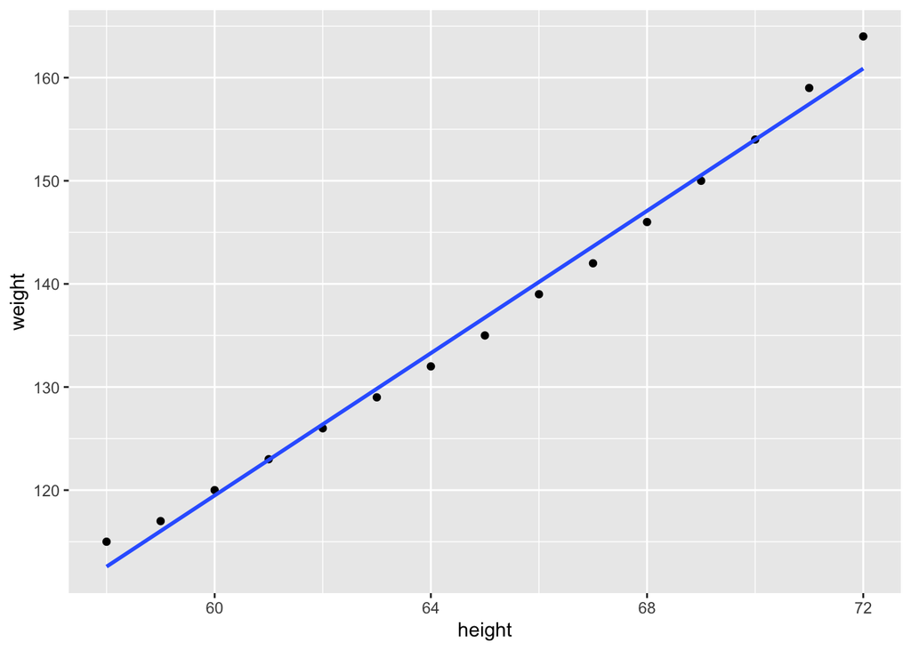

```r
womenline=lm(weight~height, data=women)
ggplot(womendata, aes(x=height, y=weight)) +
  geom_point() +
  geom_smooth(method = "lm", se = FALSE)
```

Hmm.. seems not so bad. but let’s see residuals to check:

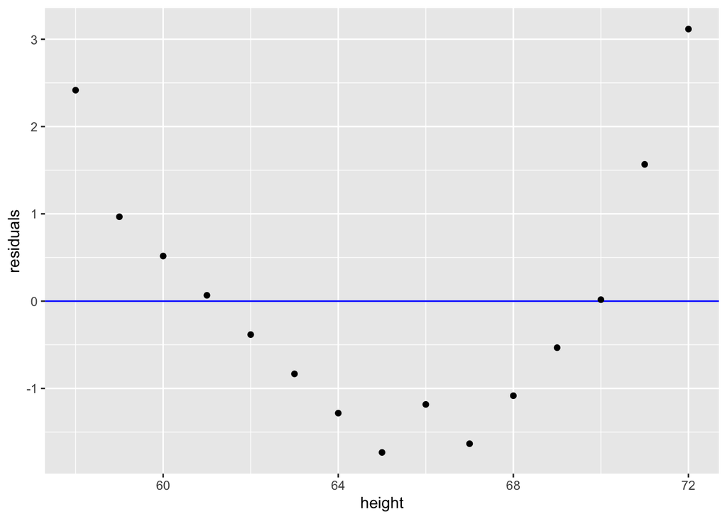

```r
womendata$residuals=residuals(womenline)

ggplot(womendata, aes(x=height, y=residuals)) +
  geom_hline(aes(yintercept = 0), color="blue") +
  geom_point()
```

Clear pattern -> linear regression not appropriate/ What does this mean? The linear regression is making systematic errors in its predictions. We should use something other than a line to model the relationship!

## Beware overrelying on $R^2$:

```r
summary(womenline)
```

```
##
## Call:
## lm(formula = weight ~ height, data = women)
##
## Residuals:
##     Min      1Q  Median      3Q     Max
## -1.7333 -1.1333 -0.3833  0.7417  3.1167
##
## Coefficients:
##              Estimate Std. Error t value Pr(>|t|)
## (Intercept) -87.51667    5.93694  -14.74 1.71e-09 ***
## height        3.45000    0.09114   37.85 1.09e-14 ***
## ---
## Signif. codes:  0 '***' 0.001 '**' 0.01 '*' 0.05 '.' 0.1 ' ' 1
##
## Residual standard error: 1.525 on 13 degrees of freedom
## Multiple R-squared:  0.991,  Adjusted R-squared:  0.9903
## F-statistic:  1433 on 1 and 13 DF,  p-value: 1.091e-14
```

High $R^2$ ! $R^2=$.991 … even though we have pattern in residuals. Having a high $R^2$ doesn’t necessarily mean the linear regression is the best model choice.

In other words, there probably is some other nonlinear relationship out there that would be better at explaining the relationship between women’s height & weights.

Limitations of regression: **ALWAYS LOOK AT THE PLOT**!

Cautionary tale: Anscombe’s quartant dataset

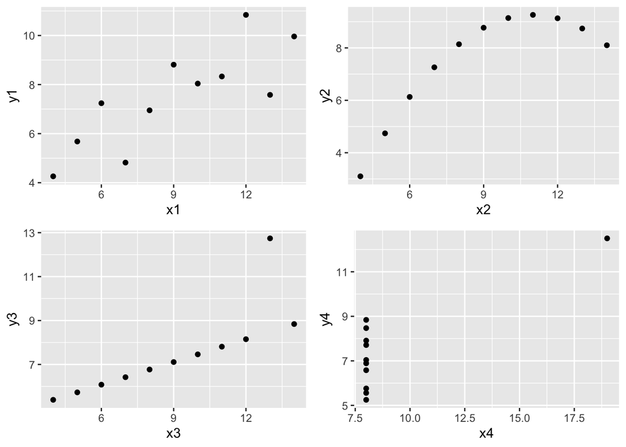

```r
g1 = ggplot(anscombe, aes(x=x1, y=y1)) +
  geom_point()
g2 = ggplot(anscombe, aes(x=x2, y=y2)) +
  geom_point()
g3 = ggplot(anscombe, aes(x=x3, y=y3)) +
  geom_point()
g4 = ggplot(anscombe, aes(x=x4, y=y4)) +
  geom_point()


#btw, gridExtra package will let us see all at once
library(gridExtra)
grid.arrange(g1, g2, g3, g4, nrow = 2)
```

Let’s see the linear regression outputs though:

```r
mod1=lm(y1~x1, data=anscombe)
mod2=lm(y2~x2, data=anscombe)
mod3=lm(y3~x3, data=anscombe)
mod4=lm(y4~x4, data=anscombe)
```

Statistics are the same:

```r
summary(mod1)
```

```
##
## Call:
## lm(formula = y1 ~ x1, data = anscombe)
##
## Residuals:
##      Min       1Q   Median       3Q      Max
## -1.92127 -0.45577 -0.04136  0.70941  1.83882
##
## Coefficients:
##             Estimate Std. Error t value Pr(>|t|)
## (Intercept)   3.0001     1.1247   2.667  0.02573 *
## x1            0.5001     0.1179   4.241  0.00217 **
## ---
## Signif. codes:  0 '***' 0.001 '**' 0.01 '*' 0.05 '.' 0.1 ' ' 1
##
## Residual standard error: 1.237 on 9 degrees of freedom
## Multiple R-squared:  0.6665, Adjusted R-squared:  0.6295
## F-statistic: 17.99 on 1 and 9 DF,  p-value: 0.00217
```

```r
summary(mod2)
```

```
##
## Call:
## lm(formula = y2 ~ x2, data = anscombe)
##
## Residuals:
##     Min      1Q  Median      3Q     Max
## -1.9009 -0.7609  0.1291  0.9491  1.2691
##
## Coefficients:
##             Estimate Std. Error t value Pr(>|t|)
## (Intercept)    3.001      1.125   2.667  0.02576 *
## x2             0.500      0.118   4.239  0.00218 **
## ---
## Signif. codes:  0 '***' 0.001 '**' 0.01 '*' 0.05 '.' 0.1 ' ' 1
##
## Residual standard error: 1.237 on 9 degrees of freedom
## Multiple R-squared:  0.6662, Adjusted R-squared:  0.6292
## F-statistic: 17.97 on 1 and 9 DF,  p-value: 0.002179
```

```r
summary(mod3)
```

```
##
## Call:
## lm(formula = y3 ~ x3, data = anscombe)
##
## Residuals:
##     Min      1Q  Median      3Q     Max
## -1.1586 -0.6146 -0.2303  0.1540  3.2411
##
## Coefficients:
##             Estimate Std. Error t value Pr(>|t|)
## (Intercept)   3.0025     1.1245   2.670  0.02562 *
## x3            0.4997     0.1179   4.239  0.00218 **
## ---
## Signif. codes:  0 '***' 0.001 '**' 0.01 '*' 0.05 '.' 0.1 ' ' 1
##
## Residual standard error: 1.236 on 9 degrees of freedom
## Multiple R-squared:  0.6663, Adjusted R-squared:  0.6292
## F-statistic: 17.97 on 1 and 9 DF,  p-value: 0.002176
```

```r
summary(mod4)
```

```
##
## Call:
## lm(formula = y4 ~ x4, data = anscombe)
##
## Residuals:
##    Min     1Q Median     3Q    Max
## -1.751 -0.831  0.000  0.809  1.839
##
## Coefficients:
##             Estimate Std. Error t value Pr(>|t|)
## (Intercept)   3.0017     1.1239   2.671  0.02559 *
## x4            0.4999     0.1178   4.243  0.00216 **
## ---
## Signif. codes:  0 '***' 0.001 '**' 0.01 '*' 0.05 '.' 0.1 ' ' 1
##
## Residual standard error: 1.236 on 9 degrees of freedom
## Multiple R-squared:  0.6667, Adjusted R-squared:  0.6297
## F-statistic:    18 on 1 and 9 DF,  p-value: 0.002165
```

Means of x’s and y’s are same:

```r
colMeans(anscombe)
```

```
##       x1       x2       x3       x4       y1       y2       y3       y4
## 9.000000 9.000000 9.000000 9.000000 7.500909 7.500909 7.500000 7.500909
```

sd’s of x’s and y’s same:

```r
apply(anscombe, 2, sd)
```

```
##       x1       x2       x3       x4       y1       y2       y3       y4
## 3.316625 3.316625 3.316625 3.316625 2.031568 2.031657 2.030424 2.030579
```